# A Glass Half Full: Analyzing a Dataset of Wine Review

## Permutation Test

We then performed a permutation test to see if the difference in the average rating of wines from Southwest France, around 88.6 points, was statistically significant from the population mean, 88.4. Somewhat surprisingly, the permutation test produced a p-value of about 0.01, which made the difference statistically significant. As the CLT implies that the sampling distribution should be approximately normal, we confirmed this p-value with pnorm, the normal cdf, which also produced a p-value of around 0.01. Finally, we generated a 95% confidence interval for the average rating of wines from SW France, 88.5 to 88.8, which does not include the population mean.

```r
# Permutation Test
# Testing the question: is wine from Southwest France statistically significantly
# different than the population of wines?
region = subset(wine, province == "Southwest France")

# The two have very close means, 88.60745 for SWF and 88.42188 for all wines
region_mean = mean(region$points); region_mean; mu
```

```
## [1] 88.63596
```

```
## [1] 88.42188
```

```r
# However, the number of wines from SWF is large, 1503. Is that enough for
# such a small difference to be significant?
nrow(region)
```

```
## [1] 1335
```

```r
n = numeric(10000)
for(i in 1:length(n)){
  s = sample(1:nrow(wine), nrow(region))
  n[i] = mean(wine$points[s]) - mu
}
hist(n, breaks = 40, prob = TRUE, main = "Difference of Sample and Population Means", xlab = "X bar - Mu", col = "orange")
abline(v = region_mean - mu, col = "red")
abline(v = mu - region_mean, col = "red")

p = mean(abs(n) > abs(region_mean - mu)); p # p = 0.0101 on the most recent run
```

```
## [1] 0.0092
```

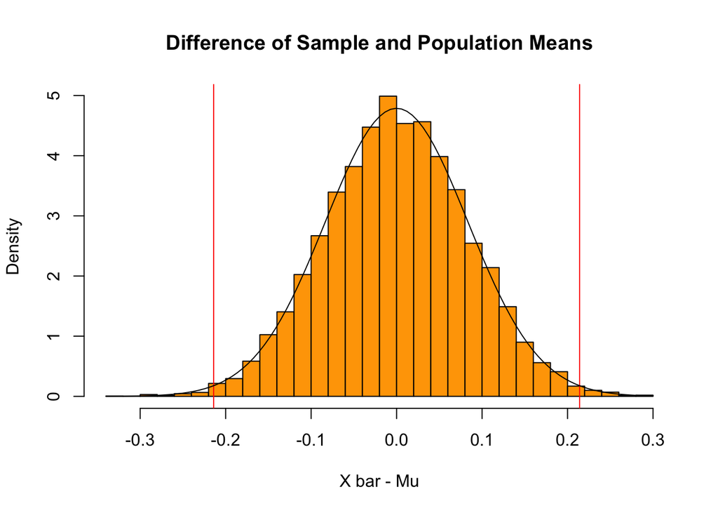

```r
# Significant at 0.05

# p-value based on a distribution function:
# By CLT, sample means should be normally distributed
sampdist_sd = sig/sqrt(nrow(region))
curve(dnorm(x, mean = 0, sd = sampdist_sd), add = TRUE)
```

```r
p = pnorm(-abs(region_mean - mu), mean = 0, sd = sampdist_sd) + pnorm(abs(region_mean - mu), mean = 0, sd = sampdist_sd, lower.tail = FALSE)

# The p-value calculations by the simulation method produced (on my specific run)
# a p-value of 0.0101, which is quite close to the classically-calculated p-value
# of 0.0102. Success!


# 95% Confidence interval of SWF points does not contain the population mean
z = abs(qnorm(0.025))
region_mean - z * sampdist_sd; region_mean + z * sampdist_sd
```

```
## [1] 88.47264
```

```
## [1] 88.79927
```

```r
mu
```

```
## [1] 88.42188
```